# Movie_dataset_engineering

### Task One (Data Cleaning):

One of the most important roles of a data analyst is to clean and make sense of the data presented to them. So, as a data analyst let's suppose you are given the task of cleaning the following dataset of Famous Movie Reviews with Python path. Take us through your data cleaning process and share the final data that you think is ready for use.

Movie dataset: https://docs.google.com/spreadsheets/d/1nUbyyp021YOclKGNqxdyxG_voAoRjsZtTVbx 0o6WJ-E/edit?usp=sharing

```python
#Importing libraries
import numpy as np
import pandas as pd
```

```python
#Reading the csv file from local drive:
movie_1 = pd.read_csv('/Users/deepakmathew/Downloads/Pending projects/Queros/Movie_dataset.csv')
movie_1.head()
```

|  | movie_title | num_critic_for_reviews | duration | DIRECTOR_facebook_likes | actor_3_facebook_likes | ACTOR_1_facebook_likes | gross | num_voted_users | Cast_Total_facebook_likes | facenumber_in_poster | num_user_for_reviews | budget | title_year | ACTOR_2_facebook_likes | imdb_score | title_year.1 |
| --- | --- | --- | --- | --- | --- | --- | --- | --- | --- | --- | --- | --- | --- | --- | --- | --- |
| 0 | Avatar?ÿ | 723 | 178.0 | 10 | 855 | 1000 | 760505847 | 886204.0 | 4834.0 | NaN | 3054 | 237000000 | 2009 | 936.0 | 7.9 | 2009.0 |
| 1 | Pirates of the Caribbean: At World's End?ÿ | 302 | NaN | 563 | 1000 | 40000 | 309404152 | 471220.0 | 48350.0 | NaN | 1238 | 300000000 | 2007 | 5000.0 | 7.1 | NaN |
| 2 | Spectre?ÿ | 602 | 148.0 | 20 | 161 | 11000 | 200074175 | 275868.0 | 11700.0 | 1.0 | 994 | 245000000 | 2015 | 393.0 | 6.8 | 2015.0 |
| 3 | The Dark Knight Rises?ÿ | 813 | NaN | 22000 | 23000 | 27000 | 448130642 | 1144337.0 | 106759.0 | NaN | 2701 | 250000000 | 2012 | 23000.0 | 8.5 | NaN |
| 4 | John Carter?ÿ | 462 | 132.0 | "475" | 530 | 640 | 73058679 | 212204.0 | 1873.0 | 1.0 | 738 | 263700000 | 2012 | 632.0 | 6.6 | NaN |

```python
#Checking the number of rows and columns:
movie_1.shape
```

```
(14, 16)
```

```python
#Checking for null values:
movie_1.isna().sum()
```

```
movie_title                  0
num_critic_for_reviews       0
duration                     3
DIRECTOR_facebook_likes      2
actor_3_facebook_likes       0
ACTOR_1_facebook_likes       0
gross                        0
num_voted_users              1
Cast_Total_facebook_likes    2
facenumber_in_poster         5
num_user_for_reviews         0
budget                       0
title_year                   0
ACTOR_2_facebook_likes       1
imdb_score                   0
title_year.1                 7
dtype: int64
```

```python
#Info about the dataset:
movie_1.info()
```

```
<class 'pandas.core.frame.DataFrame'>
RangeIndex: 14 entries, 0 to 13
Data columns (total 16 columns):
 #   Column                     Non-Null Count  Dtype
---  ------                     --------------  -----
 0   movie_title                14 non-null     object
 1   num_critic_for_reviews     14 non-null     int64
 2   duration                   11 non-null     float64
 3   DIRECTOR_facebook_likes    12 non-null     object
 4   actor_3_facebook_likes     14 non-null     int64
 5   ACTOR_1_facebook_likes     14 non-null     int64
 6   gross                      14 non-null     int64
 7   num_voted_users            13 non-null     float64
 8   Cast_Total_facebook_likes  12 non-null     float64
 9   facenumber_in_poster       9 non-null      float64
 10  num_user_for_reviews       14 non-null     int64
 11  budget                     14 non-null     int64
 12  title_year                 14 non-null     int64
 13  ACTOR_2_facebook_likes     13 non-null     float64
 14  imdb_score                 14 non-null     float64
 15  title_year.1               7 non-null      float64
dtypes: float64(7), int64(7), object(2)
memory usage: 1.9+ KB
```

```python
#Reading the column names using for:
for i in movie_1.columns:
    print(i)
```

```
movie_title
num_critic_for_reviews
duration
DIRECTOR_facebook_likes
actor_3_facebook_likes
ACTOR_1_facebook_likes
gross
num_voted_users
Cast_Total_facebook_likes
facenumber_in_poster
num_user_for_reviews
budget
title_year
ACTOR_2_facebook_likes
imdb_score
title_year.1
```

```python
#Checking the datatypes:
movie_1.dtypes
```

```
movie_title                   object
num_critic_for_reviews         int64
duration                     float64
DIRECTOR_facebook_likes       object
actor_3_facebook_likes         int64
ACTOR_1_facebook_likes         int64
gross                          int64
num_voted_users              float64
Cast_Total_facebook_likes    float64
facenumber_in_poster         float64
num_user_for_reviews           int64
budget                         int64
title_year                     int64
ACTOR_2_facebook_likes       float64
imdb_score                   float64
title_year.1                 float64
dtype: object
```

```python
movie_1['movie_title']
```

```
0                                         Avatar?ÿ
1       Pirates of the Caribbean: At World's End?ÿ
2                                        Spectre?ÿ
3                          The Dark Knight Rises?ÿ
4                                    John Carter?ÿ
5                                   Spider-Man 3?ÿ
6                                        Tangled?ÿ
7                        Avengers: Age of Ultron?ÿ
8                        Avengers: Age of Ultron?ÿ
9         Harry Potter and the Half-Blood Prince?ÿ
10            Batman v Superman: Dawn of Justice?ÿ
11                              Superman Returns?ÿ
12                             Quantum of Solace?ÿ
13    Pirates of the Caribbean: Dead Man's Chest?ÿ
Name: movie_title, dtype: object
```

```python
#Removing last 2 bias character from the dataset

movie_1['movie_title'] = movie_1['movie_title'].str[:-2]
```

```python
movie_1.head()
```

|  | movie_title | num_critic_for_reviews | duration | DIRECTOR_facebook_likes | actor_3_facebook_likes | ACTOR_1_facebook_likes | gross | num_voted_users | Cast_Total_facebook_likes | facenumber_in_poster | num_user_for_reviews | budget | title_year | ACTOR_2_facebook_likes | imdb_score | title_year.1 |
| --- | --- | --- | --- | --- | --- | --- | --- | --- | --- | --- | --- | --- | --- | --- | --- | --- |
| 0 | Avatar | 723 | 178.0 | 10 | 855 | 1000 | 760505847 | 886204.0 | 4834.0 | NaN | 3054 | 237000000 | 2009 | 936.0 | 7.9 | 2009.0 |
| 1 | Pirates of the Caribbean: At World's End | 302 | NaN | 563 | 1000 | 40000 | 309404152 | 471220.0 | 48350.0 | NaN | 1238 | 300000000 | 2007 | 5000.0 | 7.1 | NaN |
| 2 | Spectre | 602 | 148.0 | 20 | 161 | 11000 | 200074175 | 275868.0 | 11700.0 | 1.0 | 994 | 245000000 | 2015 | 393.0 | 6.8 | 2015.0 |
| 3 | The Dark Knight Rises | 813 | NaN | 22000 | 23000 | 27000 | 448130642 | 1144337.0 | 106759.0 | NaN | 2701 | 250000000 | 2012 | 23000.0 | 8.5 | NaN |
| 4 | John Carter | 462 | 132.0 | "475" | 530 | 640 | 73058679 | 212204.0 | 1873.0 | 1.0 | 738 | 263700000 | 2012 | 632.0 | 6.6 | NaN |

```python
#Checking the number of unique values:

movie_1['facenumber_in_poster'].unique()
```

```
array([nan,  1.,  4.,  3.,  2.])
```

```python
#Checking the null values

movie_1.duration.isna().sum()
```

```
3
```

```python
#movie_1['title_year.1'].nunique()
movie_1['title_year.1']
```

```
0     2009.0
1        NaN
2     2015.0
3        NaN
4        NaN
5     2007.0
6        NaN
7        NaN
8     2015.0
9        NaN
10    2016.0
11       NaN
12    2008.0
13    2008.0
Name: title_year.1, dtype: float64
```

```python
#Dropping title_year.1 and ACTOR_2_facebook_likes as they do not seem relevant. Already title year is existing in
#dataset and actor 1 is important in most of the cases than actor 2
movie_1.drop(['title_year.1','ACTOR_2_facebook_likes'], axis=1, inplace=True)
movie_1
```

|  | movie_title | num_critic_for_reviews | duration | DIRECTOR_facebook_likes | actor_3_facebook_likes | ACTOR_1_facebook_likes | gross | num_voted_users | Cast_Total_facebook_likes | facenumber_in_poster | num_user_for_reviews | budget | title_year | imdb_score |
| --- | --- | --- | --- | --- | --- | --- | --- | --- | --- | --- | --- | --- | --- | --- |
| 0 | Avatar | 723 | 178.0 | 10 | 855 | 1000 | 760505847 | 886204.0 | 4834.0 | NaN | 3054 | 237000000 | 2009 | 7.9 |
| 1 | Pirates of the Caribbean: At World's End | 302 | NaN | 563 | 1000 | 40000 | 309404152 | 471220.0 | 48350.0 | NaN | 1238 | 300000000 | 2007 | 7.1 |
| 2 | Spectre | 602 | 148.0 | 20 | 161 | 11000 | 200074175 | 275868.0 | 11700.0 | 1.0 | 994 | 245000000 | 2015 | 6.8 |
| 3 | The Dark Knight Rises | 813 | NaN | 22000 | 23000 | 27000 | 448130642 | 1144337.0 | 106759.0 | NaN | 2701 | 250000000 | 2012 | 8.5 |
| 4 | John Carter | 462 | 132.0 | "475" | 530 | 640 | 73058679 | 212204.0 | 1873.0 | 1.0 | 738 | 263700000 | 2012 | 6.6 |
| 5 | Spider-Man 3 | 392 | 156.0 | 23 | 4000 | 24000 | 336530303 | 383056.0 | 46055.0 | NaN | 1902 | 258000000 | 2007 | 6.2 |
| 6 | Tangled | 324 | NaN | 15 | 284 | 799 | 200807262 | 294810.0 | NaN | 1.0 | 387 | 260000000 | 2010 | 7.8 |
| 7 | Avengers: Age of Ultron | 635 | 141.0 | 10 | 19000 | 26000 | 458991599 | 462669.0 | 92000.0 | 4.0 | 1117 | 250000000 | 2015 | 7.5 |
| 8 | Avengers: Age of Ultron | 635 | 141.0 | 10 | 19000 | 26000 | 458991599 | 462669.0 | 92000.0 | 4.0 | 1117 | 250000000 | 2015 | 7.5 |
| 9 | Harry Potter and the Half-Blood Prince | 375 | 153.0 | 282 | 10000 | 25000 | 301956980 | 321795.0 | 58753.0 | 3.0 | 973 | 250000000 | 2009 | 7.5 |
| 10 | Batman v Superman: Dawn of Justice | 673 | 183.0 | NaN | 2000 | 15000 | 330249062 | NaN | 24450.0 | NaN | 3018 | 250000000 | 2016 | 6.9 |
| 11 | Superman Returns | 434 | 169.0 | NaN | 903 | 18000 | 200069408 | 240396.0 | NaN | 2.0 | 2367 | 209000000 | 2006 | 6.1 |
| 12 | Quantum of Solace | 403 | 106.0 | 395 | 393 | 451 | 168368427 | 330784.0 | 2023.0 | 1.0 | 1243 | 200000000 | 2008 | 6.7 |
| 13 | Pirates of the Caribbean: Dead Man's Chest | 313 | 151.0 | 563 | 1000 | 40000 | 423032628 | 522040.0 | 48486.0 | 2.0 | 1832 | 225000000 | 2006 | 7.3 |

```python
#Checking the shape of dataset after the drop fucntion
movie_1.shape
```

```
(14, 14)
```

```python
#Checking the column names
movie_1.columns
```

```
Index(['movie_title', 'num_critic_for_reviews', 'duration',
       'DIRECTOR_facebook_likes', 'actor_3_facebook_likes',
       'ACTOR_1_facebook_likes', 'gross', 'num_voted_users',
       'Cast_Total_facebook_likes', 'facenumber_in_poster',
       'num_user_for_reviews', 'budget', 'title_year', 'imdb_score'],
      dtype='object')
```

```python
#importing the plotting libraries
import matplotlib.pyplot as plt
import seaborn as sns
```

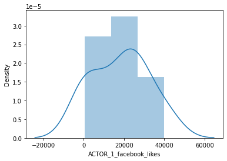

```python
#Plotting the Distribution plot
sns.distplot(movie_1['ACTOR_1_facebook_likes'])
```

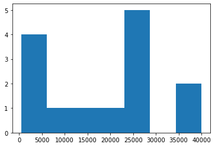

```python
#Plotting the histogram
plt.hist(movie_1['ACTOR_1_facebook_likes'], bins = 7)
```

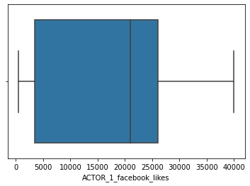

```python
#Plotting boxplot
sns.boxplot(movie_1['ACTOR_1_facebook_likes'])
```

```python
#Describe function for the statistical analysis
#movie_1.describe(include='O')

movie_1.describe()
```

|  | num_critic_for_reviews | duration | actor_3_facebook_likes | ACTOR_1_facebook_likes | gross | num_voted_users | Cast_Total_facebook_likes | facenumber_in_poster | num_user_for_reviews | budget | title_year | imdb_score |
| --- | --- | --- | --- | --- | --- | --- | --- | --- | --- | --- | --- | --- |
| count | 14.000000 | 11.000000 | 14.000000 | 14.000000 | 1.400000e+01 | 1.300000e+01 | 12.000000 | 9.000000 | 14.000000 | 1.400000e+01 | 14.000000 | 14.000000 |
| mean | 506.142857 | 150.727273 | 5866.142857 | 18206.428571 | 3.335836e+08 | 4.621578e+05 | 44773.583333 | 2.111111 | 1620.071429 | 2.462643e+08 | 2010.500000 | 7.171429 |
| std | 169.069789 | 21.679903 | 8289.592695 | 13905.214361 | 1.720674e+08 | 2.687059e+05 | 37290.813335 | 1.269296 | 866.672102 | 2.426823e+07 | 3.632122 | 0.673028 |
| min | 302.000000 | 106.000000 | 161.000000 | 451.000000 | 7.305868e+07 | 2.122040e+05 | 1873.000000 | 1.000000 | 387.000000 | 2.000000e+08 | 2006.000000 | 6.100000 |
| 25% | 379.250000 | 141.000000 | 611.250000 | 3500.000000 | 2.002574e+08 | 2.948100e+05 | 9983.500000 | 1.000000 | 1024.750000 | 2.390000e+08 | 2007.250000 | 6.725000 |
| 50% | 448.000000 | 151.000000 | 1000.000000 | 21000.000000 | 3.198266e+08 | 3.830560e+05 | 47202.500000 | 2.000000 | 1240.500000 | 2.500000e+08 | 2009.500000 | 7.200000 |
| 75% | 635.000000 | 162.500000 | 8500.000000 | 26000.000000 | 4.418561e+08 | 4.712200e+05 | 67064.750000 | 3.000000 | 2250.750000 | 2.560000e+08 | 2014.250000 | 7.500000 |
| max | 813.000000 | 183.000000 | 23000.000000 | 40000.000000 | 7.605058e+08 | 1.144337e+06 | 106759.000000 | 4.000000 | 3054.000000 | 3.000000e+08 | 2016.000000 | 8.500000 |

```python
#Checking the correlation between columns
movie_1.corr()
```

|  | num_critic_for_reviews | duration | actor_3_facebook_likes | ACTOR_1_facebook_likes | gross | num_voted_users | Cast_Total_facebook_likes | facenumber_in_poster | num_user_for_reviews | budget | title_year | imdb_score |
| --- | --- | --- | --- | --- | --- | --- | --- | --- | --- | --- | --- | --- |
| num_critic_for_reviews | 1.000000 | 0.379700 | 0.556690 | -0.152751 | 0.530223 | 0.677601 | 0.266123 | 0.504509 | 0.537845 | -0.073142 | 0.680315 | 0.448643 |
| duration | 0.379700 | 1.000000 | -0.156249 | 0.167921 | 0.472500 | 0.461035 | 0.008910 | 0.277596 | 0.792861 | 0.210596 | 0.017719 | 0.107583 |
| actor_3_facebook_likes | 0.556690 | -0.156249 | 1.000000 | 0.393330 | 0.384864 | 0.506331 | 0.913854 | 0.953002 | 0.041342 | 0.116741 | 0.445944 | 0.568646 |
| ACTOR_1_facebook_likes | -0.152751 | 0.167921 | 0.393330 | 1.000000 | 0.246350 | 0.211015 | 0.699864 | 0.695617 | 0.089682 | 0.303722 | -0.179824 | 0.109751 |
| gross | 0.530223 | 0.472500 | 0.384864 | 0.246350 | 1.000000 | 0.748385 | 0.336937 | 0.851267 | 0.564482 | 0.009834 | 0.055346 | 0.586162 |
| num_voted_users | 0.677601 | 0.461035 | 0.506331 | 0.211015 | 0.748385 | 1.000000 | 0.422842 | 0.641176 | 0.718119 | 0.052910 | 0.070622 | 0.739803 |
| Cast_Total_facebook_likes | 0.266123 | 0.008910 | 0.913854 | 0.699864 | 0.336937 | 0.422842 | 1.000000 | 0.985620 | -0.002314 | 0.242613 | 0.202191 | 0.584168 |
| facenumber_in_poster | 0.504509 | 0.277596 | 0.953002 | 0.695617 | 0.851267 | 0.641176 | 0.985620 | 1.000000 | 0.148370 | 0.183935 | 0.350931 | 0.441588 |
| num_user_for_reviews | 0.537845 | 0.792861 | 0.041342 | 0.089682 | 0.564482 | 0.718119 | -0.002314 | 0.148370 | 1.000000 | -0.270067 | -0.071929 | 0.089390 |
| budget | -0.073142 | 0.210596 | 0.116741 | 0.303722 | 0.009834 | 0.052910 | 0.242613 | 0.183935 | -0.270067 | 1.000000 | 0.202070 | 0.206214 |
| title_year | 0.680315 | 0.017719 | 0.445944 | -0.179824 | 0.055346 | 0.070622 | 0.202191 | 0.350931 | -0.071929 | 0.202070 | 1.000000 | 0.254887 |
| imdb_score | 0.448643 | 0.107583 | 0.568646 | 0.109751 | 0.586162 | 0.739803 | 0.584168 | 0.441588 | 0.089390 | 0.206214 | 0.254887 | 1.000000 |

[figure not shown]

```python
#Plotting the correlation
plt.figure(figsize=(10,10))
sns.heatmap(movie_corr, square = True, annot = True)
```

```python
movie_1['DIRECTOR_facebook_likes'].unique()
```

```
array(['10', '563', '20', '22000', '"475"', '23', '15', '282', nan, '395'],
      dtype=object)
```

```python
#replacong the string with the number

movie_1 = movie_1.replace(['"475"'],'475')
```

```python
#Finding the unique values

movie_1['DIRECTOR_facebook_likes'].unique()
```

```
array(['10', '563', '20', '22000', '475', '23', '15', '282', nan, '395'],
      dtype=object)
```

```python
#checking the dtype of DIRECTOR_facebook_likes

movie_1['DIRECTOR_facebook_likes'].dtype
```

```
dtype('O')
```

```python
#Creating a duplicate column of DIRECTOR_facebook_likes

dupl = movie_1['DIRECTOR_facebook_likes']
```

```python
dupl.isna().any()
```

```
True
```

```python
dupl = dupl.dropna()
```

```python
#Converting from obj datatype to obj from 'dupl dataset'
print(dupl)
```

```
0        10
1       563
2        20
3     22000
4       475
5        23
6        15
7        10
8        10
9       282
12      395
13      563
Name: DIRECTOR_facebook_likes, dtype: object
```

```python
dupl.columns = ['D_likes']
print(dupl)
```

```
0        10
1       563
2        20
3     22000
4       475
5        23
6        15
7        10
8        10
9       282
12      395
13      563
Name: DIRECTOR_facebook_likes, dtype: object
```

```python
#Converting the datatype to int
dupl.astype(int)
```

```
0        10
1       563
2        20
3     22000
4       475
5        23
6        15
7        10
8        10
9       282
12      395
13      563
Name: DIRECTOR_facebook_likes, dtype: int64
```

```python
dupl.mode()
```

```
0    10
dtype: object
```